# Прогнозирование потребления муниципальных образований

Конкурс СберИндекса · направление «Прогнозирование»

Александр Виноградов

## Задача

Прогнозировать потребление в муниципальных образованиях и заранее выявлять точки структурных изменений.

Данные — потребительские безналичные расходы СберИндекса по муниципальным образованиям, помесячно.

Муниципальных образований

2 190

в выгрузке дашборда; в оценке — ряды без длинных пропусков

Точек на ряд

24

два года помесячно

Период

2023–2024

с января 2023 по декабрь 2024; раньше панели нет

Категорий трат

6

целевой ряд — «все категории»

Двадцать четыре точки на ряд определяют в этой работе всё.

## Главный вывод

Задача только выглядит как прогноз двух тысяч муниципалитетов

На деле это прогноз **одного числа** и разнос его по территориям.

Разброс между муниципалитетами

695–849 ₽

Один и тот же у всех 18 сочетаний модели и фолда, стандартное отклонение 47 ₽. Разброс модели не различает.

Промах мимо общего движения

Вот где гуляет MAE. Различает модели только промах мимо общего движения страны: остальное не сдвинула ни одна из шести моделей разложения.

Конструкция

Один ряд, потом доли

Двухэтапная модель прогнозирует **один** федеральный ряд и разносит его долями. На фолде с самой короткой историей она лучшая из всех.

Средняя ошибка по трём фолдам, ₽: промах мимо общего движения + разброс

наивная

**1 088** + 764

двухэтапная

**629** + 764

базовая панельная

**668** + 798

общий фактор + категории

**459** + 758

промах мимо общего движенияразброс между муниципалитетами

## Первая находка: ловушка годовой сезонности

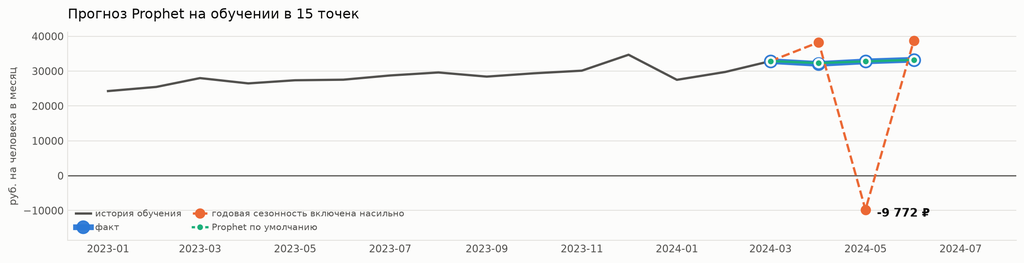

Цена одного флага

Годовая сезонность на 15 точках не идентифицируется — **прогноз уходит в отрицательные значения**. Prophet предупреждает об этом сам.

Один флаг: на полной панели MAE **22 527 ₽** против 1 581 у эталона — в **14 раз** больше, R² пул −9,19; подгонка дороже.

Эталон конкурса при этом в порядке

Prophet по умолчанию задаёт `yearly_seasonality=‘auto’` и на истории короче 730 дней сам её не включает, выводя предупреждение; ловушка срабатывает только при ручном включении сезонности. Эталон обходит наивный прогноз на 14,7%, так что планка настоящая.

## Архитектура решения

[figure not shown]

Протоколы в конфигах

Основной — `configs/full.yaml`, пилот на 300 рядах — `configs/baseline.yaml`; горизонты — `configs/horizons.yaml`, разладки — `configs/changepoints.yaml`.

Принцип

В коде моделей нет ни горизонта, ни правил разбиения: что, на чём и как проверять, решает конфиг, а не модель.

## Сравнение моделей прогнозирования

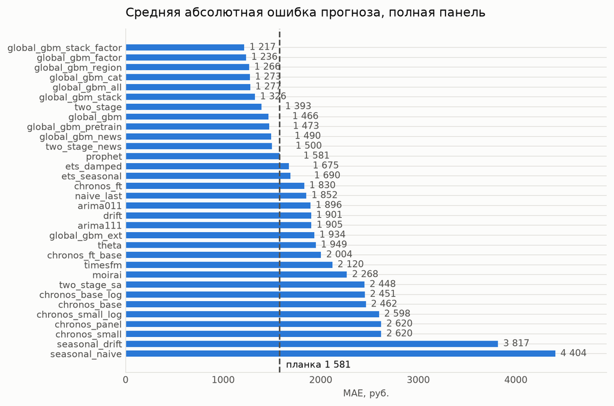

Моделей в сравнении

32

конструкции на одном протоколе: 3 фолда, горизонт 3 мес., вся панель.

Что видно

Классические модели — **потолок подхода «одна модель на ряд»**: ни одна из них не обходит эталон.

Оговорка

Насильная годовая сезонность не показана, чтобы не сжимать шкалу: её число — на слайде о ловушке.

## Метрики рядом: MAE, MASE, R²

| модель | MAE, ₽ | MASE | R² пул | R² медиана | MAE к Prophet, % |
| --- | --- | --- | --- | --- | --- |
| фактор + категории рядами | 1 217 | 0,62 | 0,978 | 0,31 | +23,0 |
| двухэтапная | 1 393 | 0,75 | 0,974 | −0,40 | +11,9 |
| базовая панельная | 1 466 | 0,73 | 0,970 | −0,13 | +7,3 |
| эталон конкурса | 1 581 | 0,84 | 0,961 | −0,57 | 0,0 |
| дообученный Chronos | 1 830 | 0,97 | 0,957 | −0,56 | −15,8 |
| наивная | 1 852 | 1,01 | 0,935 | −1,01 | −17,2 |

Лучшая к эталону по MAE

+23,0 %

фактор + категории рядами: 1 217 против 1 581 ₽ у эталона; MASE 0,62, R² по пулу 0,978.

Почему в таблице нет среднего R²

Среднее R² по парам ряд × фолд в таблицы не идёт: на трёх тестовых точках оно вырождено — от −39,0 до −7,3, и лучшей по нему выходит наивная модель, худшая по MAE.

## Что дало выигрыш

Не более хитрая модель одного ряда, а информация со стороны

Глобальная модель обучается на всей панели сразу и предсказывает **отношение к последнему значению**, а не уровень.

Один масштаб для всех

Магадан с 74 тыс. руб. и сельский район с 10 тыс. становятся сопоставимы: модель учится на форме динамики, а не на масштабе.

Панель без переноса

+7,3 %

Столько даёт сама панельная постановка над эталоном конкурса, без внешних источников.

Откуда остальное

Остальное — два внешних источника: общий фактор из длинной истории и категории трат как обучающие ряды.

MAE на полной панели, горизонт 3 мес., ₽, и выигрыш к эталону

эталон конкурса, Prophet

**1 581** · эталон

панельная модель без переноса

**1 466** · +7,3 %

+ общий фактор из длинной истории

**1 236** · +21,8 %

+ категории трат как обучающие ряды

**1 217** · +23,0 %

## Перенос с длинных рядов: чего не хватает панели

Апреля, мая и июня в обучении нет ни разу

Первый фолд (в таблицах — фолд 0): обучение кончается мартом 2024, прогнозируем апрель-июнь. Признакам нужно шесть точек истории, поэтому целевые месяцы в обучении — только июль-декабрь и январь-март.

янв2023

фев2023

мар2023

апр2023

май2023

июн2023

июл2023

авг2023

сен2023

окт2023

ноя2023

дек2023

янв2024

фев2024

мар2024

апр2024

май2024

июн2024

июл2024

авг2024

сен2024

окт2024

ноя2024

дек2024

история для признаков: 6 мес.целевые месяцы обучения: 9тест фолда 0: 3следующие фолды: 6

Панельная модель

не может знать апрельскую сезонность: в её обучении таких месяцев нет.

Федеральный ряд расходов

93 месяца

видел пять апрелей и знает форму этого месяца.

Связь измерена

0,91 и 1,23

корреляция темпов роста с панелью и эластичность.

Чего нет в обучении, панель не выучит: форму месяца даёт длинный ряд.

## Переносится не всё и не как угодно

| конструкция | MAE, ₽ | Δ к базовой |
| --- | --- | --- |
| **общий фактор + категории рядами** | **1 217** | **−249 ₽** |
| общий фактор из длинной истории | 1 236 | −230 ₽ |
| доли категорий как признаки | 1 273 | −193 ₽ |
| категории как обучающие ряды | 1 326 | −140 ₽ |
| базовая, без внешних источников | 1 466 | — |
| предобучение на отраслевых рядах | 1 473 | +6 ₽ |
| те же ряды как внешние регрессоры | 1 934 | **+467 ₽** |

Итог

Лучшая конструкция

−249 ₽

общий фактор + категории рядами

Как читать

Δ — к базовой панельной модели без внешних источников: минус помогает, плюс мешает.

## Среднее скрывает перемену мест

| модель (MAE, ₽) | фолд 0: обучение 15 мес. | фолд 1: обучение 18 мес. | фолд 2: обучение 21 мес. |
| --- | --- | --- | --- |
| наивная | **805** | 1 218 | 3 535 |
| базовая панельная | 2 387 | 1 128 | **883** |
| общий фактор + категории | 1 641 | **845** | 1 165 |

фолд 0: обучение 15 мес · лидер

805 ₽

**наивная**; базовая панельная 2 387, общий фактор + категории 1 641

фолд 1: обучение 18 мес · лидер

845 ₽

**общий фактор + категории**; наивная 1 218, базовая панельная 1 128

фолд 2: обучение 21 мес · лидер

883 ₽

**базовая панельная**; наивная 3 535, общий фактор + категории 1 165

Первый фолд

**Наивную не обходит ни одна панельная**, на третьем она же худшая — ни одна модель не берёт все три фолда.

Разложение ошибки первого фолда

Модель предсказывает падение на 8,3%, факт — рост на 1,1%; **две трети ошибки — общее смещение**, а не разброс по рядам.

## Двухэтапная модель как конструкция

| модель (MAE, ₽) | фолд 0: обучение 15 мес. | фолд 1: обучение 18 мес. | фолд 2: обучение 21 мес. | среднее |
| --- | --- | --- | --- | --- |
| наивная | 805 | 1 218 | 3 535 | 1 852 |
| **двухэтапная, сырой агрегат** | **781** | 1 587 | 1 811 | 1 393 |
| двухэтапная, сглаженный агрегат | 2 592 | 1 218 | 3 535 | 2 448 |

Тождество с наивной

460 ₽ из 1 852

Разброс двухэтапной модели **совпадает с наивной до рубля** — 695, 774 и 824: тождество по построению, обе дают «последнее значение × общий множитель». Разница между ними — ровно общий фактор.

Почему не сглаженный агрегат

Сглаживание вычищает именно ту сезонность, которую разнос делит между муниципалитетами, и доля перестаёт быть устойчивой. Внутренний бэктест выбирает на нём `random_walk`.

Самое короткое обучение

781 ₽

Фолд 0: сырой агрегат точнее наивной (805) и базовой панельной (2 387). Когда истории мало, выигрывает конструкция, а не обучение.

| модель (MAE, ₽) | наукаст (9 фолдов) | 3 мес (3) | 6 мес (2) | 12 мес (1) |
| --- | --- | --- | --- | --- |
| наивная | 1 611 | 1 852 | 2 632 | 2 691 |
| эталон конкурса | 1 550 | 1 581 | 2 137 | 2 722 |
| **фактор + категории рядами** | **839** | **1 217** | **1 442** | нет примеров |
| двухэтапная | 1 018 | 1 393 | 1 749 | **1 642** |

наукаст · ●●●●●●●●●

−45,9 %

фактор + категории рядами: 839 против 1 550 у эталона

3 мес. · ●●●

−23,0 %

фактор + категории рядами: 1 217 против 1 581 у эталона

6 мес. · ●●

−32,5 %

фактор + категории рядами: 1 442 против 2 137 у эталона

12 мес. · ●

−39,7 %

двухэтапная: 1 642 против 2 722 у эталона

Наукаст

**Наукаст: 45,9% над эталоном.** Известный агрегат за текущий месяц добавляет 21,4 рубля: движение страны на месяц предсказуемо, остаток — разброс.

Год вперёд

**У панельных моделей нет обучающих примеров**, двухэтапная обходит эталон на 40%. Даже оракул общего движения не разносит точнее 1 356.

Что растёт

**Ошибка растёт не с расстоянием, а с календарём.** От декабря наивная ошибается на 7 036 в январе и на 1 211 в августе.

## Прогноз на 2025 год: первый этап сверен с фактом

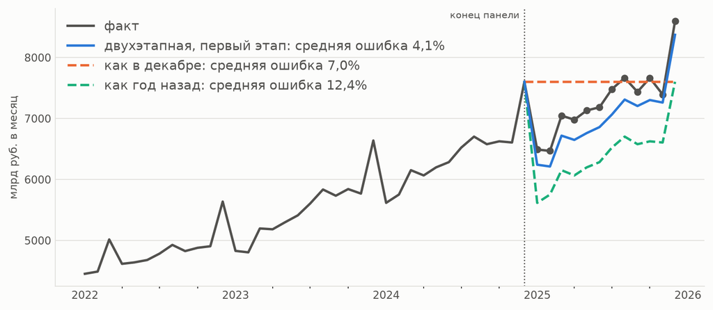

Первый этап · средняя ошибка

4,1 %

первый этап двухэтапной модели за весь год

«как в декабре»

7,0 %

«как год назад»

12,4 %

Что это значит

Прогноз ниже факта все 12 месяцев: первый этап берёт медианный прирост 2019–2024, а 2025-й рос быстрее.

Муниципальный разрез 2025 года ещё не опубликован: фактом проверен только первый этап.

## Короче история — ценнее перенос

Выигрыш переноса (общий фактор + категории) к базовой модели при той же длине обучения: минус помогает, плюс мешает.

обучение 12 мес

−7 590 ₽

базовая модель: MAE 9 213 ₽

обучение 15 мес

−746 ₽

базовая модель: MAE 2 387 ₽

обучение 18 мес

−283 ₽

базовая модель: MAE 1 128 ₽

обучение 21 мес

+281 ₽

базовая модель: MAE 883 ₽

девять дополнительных месяцев

в 10,4 раза

Наивную модель тот же срок не улучшает вовсе: её ошибка зависит от того, какие месяцы попали в тест, а не от длины истории.

Что это значит для практики

Прогнозировать предстоит с 24 месяцами обучения — за правым краем развёртки. Для практики берём не лучшую по среднему модель, а лучшую на самом длинном обучении.

## Почему регрессоры проваливаются

Федеральный ряд в месяце *t* одинаков для всех 2028 муниципалитетов

Значений в обучении фолда ровно столько, сколько там моментов. Это метка месяца, а не регрессор.

На всё обучение первого фолда

9 значений

разных значений признака — столько же, сколько месяцев.

В тесте

треть признаков

вне диапазона обучения, и дерево там отдаёт константу.

Общий фактор работает иначе

Длинный ряд отвечает на вопрос, на который короткий не может: какова сезонная форма месяца, которого в обучении не было.

Тот же ряд как внешний регрессор

1 934 ₽

+467 ₽ к базовой панельной модели (1 466): дерево получает метку месяца и в тесте отдаёт константу.

Тот же ряд как общий фактор

1 236 ₽

−230 ₽ к базовой: ряд задаёт общий множитель прогноза, а не столбец признаков.

## Обнаружение разладок: решает преобразование

| метод | обнаружено, % | задержка, медиана, мес. | ложных, % | J Юдена | сырые: ложных, % | сырые: J |
| --- | --- | --- | --- | --- | --- | --- |
| PELT | 13,9 | 3 | 0,0 | +13,9 | 66,7 | −31,3 |
| BinSeg | 13,9 | 3 | 0,0 | +13,9 | 66,7 | −31,7 |
| BottomUp | 11,9 | 3 | 0,0 | +11,9 | 53,3 | −25,3 |
| ядровой | 4,7 | 3 | 0,0 | +4,7 | 66,7 | −45,8 |
| Window | 3,8 | 3 | 0,0 | +3,8 | 73,3 | −42,5 |
| CUSUM | 20,1 | 1 | 58,3 | −38,2 | 100,0 | −81,1 |

Стенд и зачёт

Штраф 5 — по стенду, до реальных данных, край сетки: лучший мог лежать за ним. Зачёт — не позже 3 мес. после врезки, при молчащем нетронутом близнеце. Лучший J — у PELT и BinSeg. **Но у методов со штрафом на темпах роста 64,4–79,7% засчитанного — сигналы в декабре; у PELT без них 4,6%.**

Что это значит

**На сырых рядах детекторы ловят сезонность и структуру рядов, а не изломы.** Первые четыре столбца таблицы — темпы роста, два последних — сырые ряды.

## Интерпретация на реальных данных

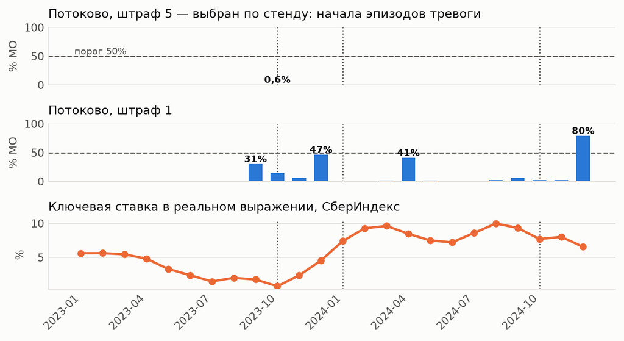

| ранговый вид | штраф 5 | штраф 1 |
| --- | --- | --- |
| октябрь 2023 | 1 из 16 (0,6%) | 5 из 16 (14,4%) |
| январь 2024 | 10,5 из 16 (0%) | 14 из 16 (0,2%) |
| октябрь 2024 | 10,5 из 16 (0%) | 8 из 16 (2,4%) |

Штраф 5, выбран по стенду

порог 50% не перейдён ни разу, наибольшая доля — 0,6% (октябрь 2023); октябрь 2023 — первый по доле месяц, но это 12 МО из 2 028; фон нулевой.

Штраф 1

октябрь 2024 — порог в декабре 2024 (79,5% против 2,4 и 2,1% в октябре и ноябре — сигнал в самом декабре), задержка 2 мес.; октябрь 2023 и январь 2024 — нет (46,7 и 41,4%); сентябрь 2023 выше всех трёх событий — эффект старта; фон 2,1% (43 МО).

Задним числом, по полному ряду (штраф 1)

октябрь 2023 — 50,5%, январь 2024 — 63,7%, октябрь 2024 — 85,8%; в остальные месяцы не выше 12,1%.

## Чего мы не утверждаем

Причинность

Трёх событий недостаточно для вывода о причинности: связь с денежной политикой — совпадение и гипотеза.

Два шока или один отрезок

Октябрь 2023 и январь 2024 по полному ряду — не два шока: у 1 024 из 1 025 рядов с изломом в октябре 2023 есть излом и в январе 2024: это начало и конец одного отрезка.

Январь неотделим от сезонности

Ряд начинается в январе 2023, и детектируемый январь у нас ровно один.

Показатель — оценка среднедушевых расходов

Методология муниципального уровня не опубликована. Мы прогнозируем **опубликованный ряд**, а интерпретируем только относительные величины.

## Что не сработало: модели

Фундаментальные модели без дообучения

На горизонте 3 мес. Chronos-Bolt small проигрывает наивной на 41%, Moirai на 22%, TimesFM 2.5 на 14% — в среднем; на третьем фолде Moirai, TimesFM 2.5 и Chronos-Bolt base наивную обходят. **Три** разных семейства сходятся, значит дело не в архитектуре.

Дообучение Chronos

На том же горизонте дообучение снимает 30% ошибки (2 620 → 1 830) и доводит его лишь до уровня наивной (на 1,2% лучше): эталону уступает 15,8%, панельной модели — в 1,5 раза. На наукасте — лишь 1,6% (2 026 → 1 994), и он на 23,8% хуже наивной; на 6 и 12 мес. дообучение пропускается или отказывает. Повтор с тем же сидом расходится на третьем фолде: 2 326 (снимок локального прогона, в репозиторий не входит) против 2 337. Больше параметров в среднем хуже: дообученный base даёт 2 004 против 1 830 у small.

Ансамбль, пилот на 300 рядах

Смесь с весом по тесту давала +9,6%. При честном подборе веса — **−40%**. Оптимальный вес нестабилен между фолдами.

Как читать

Все эти результаты измерены и приведены как есть. На 24 точках почти любой метод покажет улучшение, если подбирать параметры по тем же данным, на которых меряешь.

## Что не сработало: новости и длинные ряды

Заголовков в корпусе

589 тыс.

собраны по региональным изданиям

Регионов

18

с собственными новостными рядами

Проверок всего

102

событийный анализ, корреляции с изломами и национальный уровень

Прошли порог

0

пороги объявлены до расчёта

Новости, три независимые конструкции

589 тыс. заголовков, 18 регионов. Признаки в модели на наукасте: ошибка ниже на 21,5 ₽ на 396 покрытых рядах, но интервал по фолдам [−78; +35] накрывает ноль, на всех рядах не лучше базовой. Событийный анализ на изломах, 42 проверки, и та же региональная проверка корреляцией, 12: ни одной значимой. **Национальный уровень против федерального агрегата — 48 гипотез, порог объявлен заранее, не прошла ни одна.**

Заголовки не виноваты

По выборке в 20 тыс. статей с телами тело добирает медианно **1,2%** из непопавших, а связь с целью меняется вдвое слабее шума выборки.

Длинные ряды в двух конструкциях из четырёх

Как внешние регрессоры — хуже на треть. Предобучение на 56 отраслевых рядах — интервал [−16; +29], ноль. Эластичность по регионам устойчива (корреляция половин периода 0,77), но усиливает не только сигнал, но и ошибку прогноза фактора.

## Выводы

**Главный вывод:** задача — прогноз одного числа и разнос его по территориям.

**Информация со стороны:** 23,0% к эталону (MAE, 3 мес.) против 7,3% у панели без переноса — на 2 фолдах из 3, на первом эталон точнее.

**Горизонты:** наукаст — 45,9% к эталону; на год — двухэтапная, 39% и 40% к наивной и эталону (один фолд).

**Агрегат на факте 2025 года:** ошибка первого этапа 3,8–4,5% против 7,0–17,1% у простых правил.

**Закон переноса:** при 12 мес. обучения перенос снимает 7 590 ₽, при 21 — добавляет 281 ₽ (корреляция с длиной 0,96); базовая модель при 21 мес. точнее, чем при 12, в 10,4 раза.

**Ловушка:** насильная годовая сезонность — MAE 22 527 ₽ вместо 1 581 ₽ у Prophet по умолчанию.

**Фундаментальные:** без дообучения на 3 мес. в среднем хуже наивной, дообученный Chronos — 1 830 против 1 852 ₽ у неё.

**Новости:** на наукасте ошибка ниже на 21,5 ₽ на 396 рядах, но интервал по фолдам накрывает ноль.

**Изломы:** решает преобразование — у методов со штрафом ложных 53,3–73,3% на сырых рядах, 0% на темпах роста; уровень скромный, раннего предупреждения не показано.

## Что из этого следует

Для задач такого рода длина ряда важнее выбора метода

Три дополнительных месяца истории меняют качество прогноза сильнее, чем переход от наивной модели к градиентному бустингу.

Осторожно с определённостью

Ни одна модель не выигрывает у наивной на всех трёх фолдах. По фолдам интервалы накрывают ноль у всех конструкций. Приводим обе оценки и не выбираем удобную.

Главный практический вывод

2,4 раза

На фолдах с обучением 18 и 21 точка MAE базовой панельной модели в среднем 1 006, на фолде с 15 точками — 2 387.

Что проверит факт

Прогноз на 2025 год по 2 028 рядам лежит в репозитории. Муниципальный разрез 2025 года проверит его целиком: фактом пока сверен один первый этап.

Сайт работы: kr1zal.github.io/sberindex_konkurs · код, данные и отчёт: github.com/kr1zal/sberindex_konkurs